# R Notebook

## Assignment 3

Create a New R Notebook and save it as both html format and PDF format.

Data frame for this assignment: lowbwt **1. List the level of measurement for each of the following variables:**

1. LOW: Ordinal-level
2. LWT (Weight in Pounds at the Last Menstrual Period): Interval-Ratio

**2. Why is it NOT appropriate to create a crosstab using the two variables in the previous question?**

Since LOW is an ordinal-level variable, creating a crosstab using LOW as a variable against LWT, an interval-ratio variable, sums up the count for all binary values at that level, which is not useful information (see below).

```r
table(lowbwt$LWT,lowbwt$LOW, dnn = c("Lbs at LMP", "Low Weight Baby"))
```

```
          Low Weight Baby
Lbs at LMP  0  1
       80   0  1
       85   1  1
       89   0  1
       90   3  0
       91   0  1
       92   0  1
       94   0  1
       95   5  1
       96   0  1
       97   0  1
       98   1  0
       100  3  2
       101  0  1
```

[output cut: 62 more lines]

**3. Recode the variable LWT into a new ordinal variable.**

```r
summary(lowbwt$LWT)
```

```
   Min. 1st Qu.  Median    Mean 3rd Qu.    Max.
   80.0   110.0   121.0   129.8   140.0   250.0
```

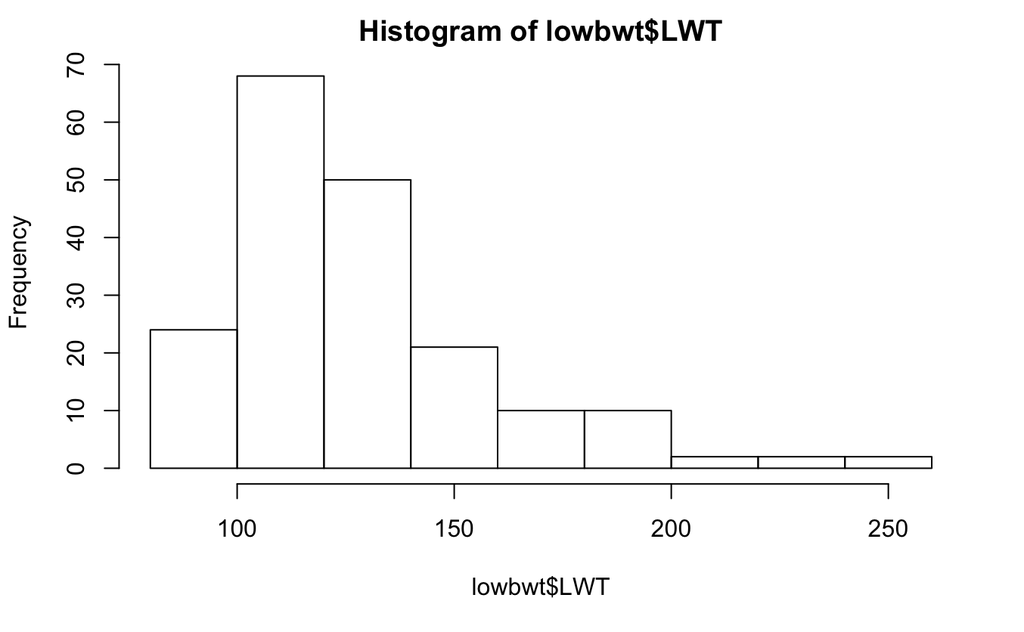

```r
hist(lowbwt$LWT)
```

```r
quantile(lowbwt$LWT,seq(0,1,0.05),na.rm=TRUE)
```

```
   0%    5%   10%   15%   20%   25%   30%   35%   40%   45%   50%   55%   60%   65%   70%
 80.0  94.4  99.6 103.0 107.0 110.0 112.4 115.0 120.0 120.0 121.0 125.0 130.0 130.2 134.6
  75%   80%   85%   90%   95%  100%
140.0 150.0 158.0 170.0 188.2 250.0
```

```r
lowbwt$LWTCat[lowbwt$LWT <= 100] <- 1
```

```
Unknown or uninitialised column: 'LWTCat'.
```

```r
lowbwt$LWTCat[lowbwt$LWT > 100 & lowbwt$LWT <= 140] <- 2
lowbwt$LWTCat[lowbwt$LWT > 140] <- 3
```

**4. Show a frequency table of the new ordinal LWT variable (that you created in #3) and explain your coding scheme.**

```r
table(lowbwt$LWTCat,useNA ="ifany")
```

[output not shown]

```r
summary(lowbwt$LWT)
```

```
   Min. 1st Qu.  Median    Mean 3rd Qu.    Max.
   80.0   110.0   121.0   129.8   140.0   250.0
```

```r
tapply(lowbwt$LWT, lowbwt$LWTCat, summary)
```

```
$`Low:<100 lbs`
   Min. 1st Qu.  Median    Mean 3rd Qu.    Max.
  80.00   90.00   95.00   93.62   97.25  100.00

$`Average:101-140lbs`
   Min. 1st Qu.  Median    Mean 3rd Qu.    Max.
    101     112     120     120     130     140

$`High:140+lbs`
   Min. 1st Qu.  Median    Mean 3rd Qu.    Max.
  141.0   153.5   168.0   172.9   186.5   250.0
```

Coding scheme: Organized LWT into based on indications by 1st and 3rd quartile. Low weight below 100 (slightly below the first quartile), average weight between 100-140, and high weight above 140 (at the third quartile).

**5. Show a crosstab of Low Birth Weight (LOW) BY Weight in Pounds at the Last Menstrual Period, making sure to use variables at the appropriate levels of measurement.**

```r
table(lowbwt$LOW, lowbwt$LWTCat, dnn = c("LOW", "LWT"))
```

```
   LWT
LOW Low:<100 lbs Average:101-140lbs High:140+lbs
  0           13                 82           35
  1           11                 36           12
```

**6. Does there appear to be a relationship between Low Birth Weight and Mother’s weight in pounds at the last menstrual period? Explain.**

```r
prop.table(table(lowbwt$LWTCat, lowbwt$LOW, dnn = c("LWT", "LOW")), 2)
```

```
                    LOW
LWT                          0         1
  Low:<100 lbs       0.1000000 0.1864407
  Average:101-140lbs 0.6307692 0.6101695
  High:140+lbs       0.2692308 0.2033898
```

There seems to be a slight relationship between LWT and LOW.

Low LWT makes up 10% of non low-weight babies, Average LWT makes up 63% and High makes up 26.9%.

This is compared to Low LWT’s 18.6% share of low birth weight babies, Average LWT’s 61% and High LWT’s 20%.

We can see that there is a slightly higher proportion of babies by low LWT among the low weight babies compared to non-low weight babies.

Submit to Canvas: your answers to these questions AND the R code you used to get the answers.

# Advanced material

Lets create a dummy variable based on a high level of gdp. As a reminder dummy variables are used very heavily in quantitative analysis. Better called “indicator variables” they use a binary coding scheme in which “1” indicates the presence of a characteristic and “0” the absense. First, lets look at the GDP variable to get a good definition of “high”

```r
summary(country$gdp)
```

```
   Min. 1st Qu.  Median    Mean 3rd Qu.    Max.    NA's
   90.0   632.8  2342.0  7993.0  7876.0 70300.0      13
```

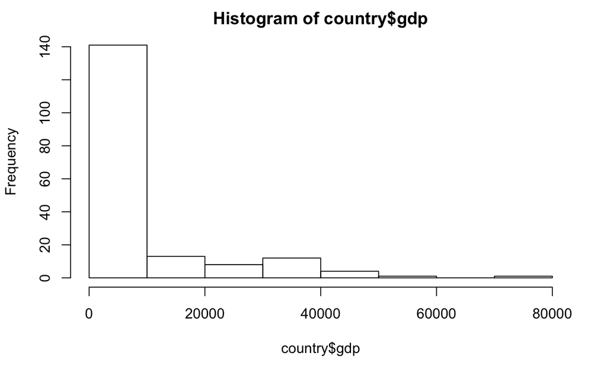

```r
hist(country$gdp)
```

The third quartile value is 7876 so lets go above that and call that “high”. Here I am going to use “if/else” logic which is common in classical programming. Note how simple the code is.

```r
country$gdphigh <- ifelse(country$gdp>7876,1,0)
tapply(country$gdp, country$gdphigh, summary)
```

```
$`0`
   Min. 1st Qu.  Median    Mean 3rd Qu.    Max.
     90     476    1184    2002    2894    7724

$`1`
   Min. 1st Qu.  Median    Mean 3rd Qu.    Max.
   8331   14140   24360   25960   35560   70300
```

When you do things over and over in programming you should eventually get used to creating functions. Functions boil down repetive tasks to a couple of fundamental steps. It is always good to first “hard code” a process (like we did above) before generalizing to a functoin. When we create a function we have to name it something and specify the ingredients we are going to add to the function. Here I am calling the function dummygen2 and am supplying 4 ingredients which, for concision, I call elements a,b,c,d a is the name of the dataset (in this example it is country) b is the name of the variable I want to create (here it would be gdphigh) c is the continous variable I want to create a dummy from (here gdp) d is the threshold i want to set up for “high” (here it is 7876)

```r
dummygen2 <- function(a,b,c,d) {

  a[,b] <- ifelse(a[,c] >d,1,0)

return(a)
}
#Now I invoke the function
dummygen2(country,"gdphigh2","gdp",7876)->country
tapply(country$gdp, country$gdphigh2, summary)
```

```
$`0`
   Min. 1st Qu.  Median    Mean 3rd Qu.    Max.
     90     476    1184    2002    2894    7724

$`1`
   Min. 1st Qu.  Median    Mean 3rd Qu.    Max.
   8331   14140   24360   25960   35560   70300
```

Here is another way to create categorical variables Here we will create various breakpoints and then use the cut function

```r
brks <- c(0,40,50,60,70, Inf)   # Note: 1
country$lifespan.range <- cut(country$lifem,
                          breaks=brks, include.lowest=T)    # Note: 2
summary(country$lifespan.range)
```

```
  [0,40]  (40,50]  (50,60]  (60,70] (70,Inf]     NA's
       9       22       24       57       67       14
```

```r
table(country$lifespan.range)
```

```
  [0,40]  (40,50]  (50,60]  (60,70] (70,Inf]
       9       22       24       57       67
```

Here is a more general dummy variable functoin. This one replaces “na” with zero. Make sure that is what you want! There are no instances where this particular code would make sense with this dataset as there are no categorical source variables but you can use this with survey data which has a long of such variables. I don’t actually apply this function here.

Missing values present many issues in data analysis. We’ll be dealing with this in future labs. Here is how you can visualize missings

```
not enough vertical space to display frequencies (too many combinations)
```

```
 Variables sorted by number of missings:
       Variable       Count
        cde2003 0.559585492
     inequality 0.347150259
         educ04 0.341968912
      milit2004 0.310880829
         debt04 0.310880829
       tele2004 0.264248705
       cell2003 0.176165803
        hdirank 0.082901554
         hdicat 0.082901554
          lifef 0.072538860
          lifem 0.072538860
 lifespan.range 0.072538860
            gdp 0.067357513
        gdphigh 0.067357513
       gdphigh2 0.067357513
     internet03 0.062176166
        pop2004 0.036269430
     physicians 0.015544041
       mort2004 0.005181347
           case 0.000000000
        country 0.000000000
      urban2004 0.000000000
```

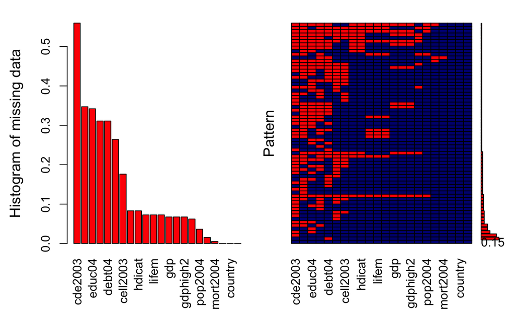

```r
install.packages("VIM")
library(VIM)
missings_plot <- aggr(country, col=c('navyblue','red'), only.miss=TRUE, numbers=TRUE, sortVars=TRUE, labels=names(country), gap=3, ylab=c("Histogram of missing data","Pattern"))
```

```
 Variables sorted by number of missings:
       Variable      Count
        hdirank 0.08290155
         hdicat 0.08290155
       gdphigh2 0.06735751
           case 0.00000000
        country 0.00000000
        pop2004 0.00000000
      urban2004 0.00000000
     physicians 0.00000000
       mort2004 0.00000000
       tele2004 0.00000000
       cell2003 0.00000000
     internet03 0.00000000
            gdp 0.00000000
     inequality 0.00000000
         educ04 0.00000000
      milit2004 0.00000000
         debt04 0.00000000
        cde2003 0.00000000
          lifef 0.00000000
          lifem 0.00000000
        gdphigh 0.00000000
 lifespan.range 0.00000000
```

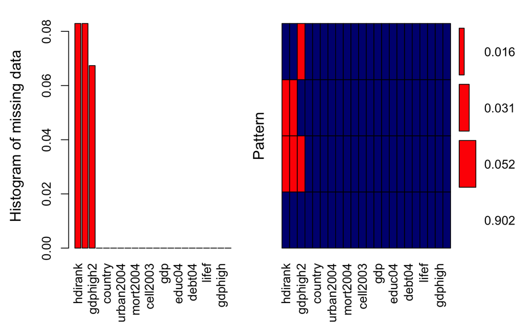

```r
install.packages("mice")
library(mice)
set.seed(144) # random number generator
imputed_country = complete(mice(country))
missings_plot <- aggr(imputed_country, col=c('navyblue','red'), only.miss=TRUE, numbers=TRUE, sortVars=TRUE, labels=names(imputed_country), gap=3, ylab=c("Histogram of missing data","Pattern"))
```

[output not shown]